# Quantitative Methods for HIV Researchers

Part II Day 2: Probability, Distributions, and Hypothesis Testing

Lynn Lin, PhD

January 26, 2021

# Introduction

## Learning Objectives and Goals

### Probability and Distribution

- Introduce random variables and probability distributions
- Define population parameters and sample statistics
- Introduce sampling distributions, the normal distribution, and the Central Limit Theorem

### Confidence Intervals

- Introduce inferential statistics
- Construct confidence intervals for population parameters

## Case Study #1

Efficacy and Tolerability of 3 Nonnucleoside Reverse Transcriptase Inhibitor-Sparing Antiretroviral Regimens for Treatment-Naive Volunteers Infected With HIV-1: A Randomized, Controlled Equivalence Trial

https://doi.org//10.7326/M14-1084

Comparison of the Metabolic Effects of Ritonavir-Boosted Darunavir or Atazanavir Versus Raltegravir, and the Impact of Ritonavir Plasma Exposure: ACTG 5257

https://doi.org/10.1093/cid/civ193

```r
Case1 <- read.csv(file="Data/data_Case1.csv", na.strings="",
    stringsAsFactors=TRUE)

# create dataset with change in LDL from week 0 to week 24
Case1LDL <- Case1 %>% filter(week %in% c(0,24)) %>%
    select(ntisid, Arm, week, LDL) %>%
    reshape(v.names=c("LDL"), timevar="week", idvar="ntisid",
        direction="wide", sep="w") %>%
    mutate(LDLchg=LDLw24-LDLw0)
```

NTISID: NTIS Identification number

WEEK: Study week

ARM: Treatment group (A=TRV+RTV+ATV, B=TRV+RAL, C=TRV+RTV+DRV)

AGE: Age at study enrollment (years)

SEX: Sex

RACE: Race

AIDS_DX: Prior AIDS diagnosis

CVDHX: CVD history

MODET: Mode of HIV transmission

IVDRUG: History of injection drug use

DRINKER: Alcohol drinking category

HEPB: Hepatitis B surface antigen status (1=positive, 2=negative)

HEPC: Hepatitis C virus status (1=positive, 2=negative)

CRCL_BSL: Calculated creatinine clearance (mL/min/1.73m2)

SEXPREF: Sex partner preference

HOWSURE1: Sure take all/most of HIV meds

HOWSURE2: Sure HIV meds have positive effect?

HIVRNA: HIV-1 RNA (copies/ml)

CD4: CD4+ cell count, closest to the visit window (cells/mm3)

CD8: CD8+ cell count (cells/mm3)

SBP: Systolic blood pressure (mmHg)

EGFR_MDRD: Estimated glomerular filtration rate (mL/min/1.73m2)

TRIGS: Fasting triglycerides (mg/dL)

LDL: Fasting calc LDL-C (mg/dL)

FPG: Fasting glucose (mg/dL)

BMI: Body mass index (kg/m2)

EVERSMOKER: Smoking history

HEALTH: In general, would you say your health is?

WGHTNOW: Think about your weight today, do you consider yourself to be?

WGHTAGO: Thinking about your weight now and your weight a year ago, are you more or less worried about your weight than before?

## Case Study #2

A Superiority of Viral Load Over CD4 Cell Count When Predicting Mortality in HIV patients On Therapy

https://doi.org/10.1186/s12879-019-3781-1

```r
Case2 <- read.csv(file=paste0("Data/data_Case2.csv"), na.strings="", stringsAsFactors=TRUE)
Case2$VL[which(Case2$VL<50)] <- 50  # if VL <50, set to 50, the lower limit
Case2$VL[which(Case2$VL>500000)] <- 500000  # set to upper limit
Case2 <- Case2 %>%  mutate(log10VL=log10(VL),
      VLud=ifelse(VL<=50, 1, 0))  # indicator for undetectable VL

# Create vector of virologic control over follow-up indicator
getVC <- function(x){  # x will be a vector of 0s, 1s, or NAs
    ifelse( any(x==0, na.rm=TRUE), 0, 1)
}

# apply the function above to the follow-up data only
# (no one in control at baseline)
Case2fup <- Case2 %>% filter(t !=0) %>% droplevels  #  follow-up data
VC <- tapply(Case2fup$VLud, Case2fup$SID, getVC)

# Merge it with the baseline data
Case2VC <- Case2 %>% filter(t==0) %>% select(SID, NonAdhBL) %>%
    merge(y=VC, by.x="SID", by.y=0, all=TRUE) %>%
    rename(VCfup=y) %>% droplevels()

rm(Case2fup, getVC, VC)  # clean up to prevent confusion
```

SID: Participant identifier

RxClass: HIV medication class combination

NonAdhBL: Medication non-adherence status (0=adherent, 1=non-adherent)

t: Time (years)

Age: Age at enrollment (years)

Sex: Sex (0=female, 1=male)

Weight: Weight (kg)

VL: HIV RNA (copies/mL)

CD4: CD4 cell count (cells/mm3)

Death: Indicator of participant death (0=no, 1=yes)

# Probability and Distributions

## Definitions

- **Population**: a collection of elements of interest (in clinical research, usually humans)
- **Variable**: a characteristic that takes different values for different elements in the population
- **Random sample**: a subset of independently and randomly selected elements from a population
- **Random variable**: a characteristic that takes different values for different elements in sample
- **Sample space**: the set of all possible outcomes of a random variable
- **Event**: any subset of interest of the possible outcomes in the sample space
- **Probability**: relative frequency of an outcome to all possible outcomes in the sample space; denoted $P(Y \epsilon A)$, where Y is a random variable and A is a subset of the sample space

### Case #1

**Population**: “Treatment-naive persons aged 18 years or older with HIV-1 RNA levels greater than 1000 copies/mL without resistance to nucleoside reverse transcriptase inhibitors or protease inhibitors.”

**Variable**: Change in LDL cholesterol after HIV treatment

**Random sample**: Randomly select 300 individuals

**Random variable**: Measure change in LDL from week 0 to week 24 in the 300 individuals

**Sample space**: Theoretically, $(-\infty, \infty)$, practically…?

**Event**: Someone chosen at random will have a change in LDL $>10$ mg/dL

**Probability**: $P(Y>10)$; can be estimated from sample

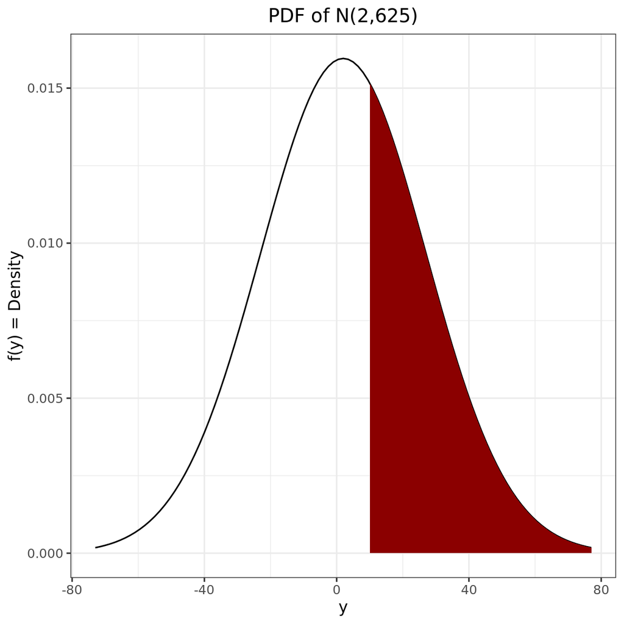

```r
ggplot(data.frame(y = c(-73, 77)), aes(y)) +
  stat_function(fun = dnorm, args=list(mean= 2, sd=25)) +
  stat_function(fun = dnorm,
                args=list(mean= 2, sd=25),
                xlim = c(10,77),
                geom = "area",
                fill="darkred") +
  labs(title="PDF of N(2,625)",
       y="f(y) = Density") +
  theme_bw()+
  theme(plot.title = element_text(hjust = 0.5))
```

### Case #2

**Population**: “HIV-infected patients…at a Wellness clinic in Bela Bela, South Africa, from year 2005 to year 2009…15 years and older.”

**Variable**: Virologic control over follow-up (HIV RNA <50 copies/mL)

**Random sample**: randomly select 320 individuals

**Random variable**: ?

**Sample space**: ?

```r
# random variable: [type answer here]
# sample space: [type answer here]
```

## Random Variables and Probability Distributions

A **random variable** is a characteristic that takes different values for different elements in sample.

Random variables are denoted by uppercase letters, typically X, Y, or Z.

Random variables can be discrete: the values are countable, isolated

Hospital readmissions after initial discharge (0, 1, 2, …); virologic control

Random variables can be continuous: the values are on a continuum, uncountable

Age, BMI, viral load, change in LDL, CD4, recovery time after surgery

**Probability mass function (PMF)**: a function that maps every possible value of a discrete random variable to the probability of that value.

**Probability density function (PDF)**: a curve that specifies the probability (area under the curve) that a continuous random variable falls within a certain interval.

## Probability Mass Functions for Discrete Random Variables

Denoted as $f_Y (y)$. Maps the realization $y$ of a random variable $Y$ to a probability. In other words, $f_Y (y_i )=P(Y=y_i)$.

Properties:

1. $0 \le f_Y (y_i ) \le 1$, for all $y_i$ in the sample space
2. $\sum_i f_Y (y_i) = 1$

$f_Y (y_i)$ can be displayed as a table, graph, or mathematical expression.

### Example

**Population**: Babies born at Duke Regional Hospital

**Variable**: Number of babies with type O blood

**Random sample**: four babies

**Random variable**: $Y$ = the number of babies (out of 4) with type O blood

The PMF of $Y$ is given in the table below.

| Y=y | 0 | 1 | 2 | 3 | 4 |
| --- | --- | --- | --- | --- | --- |
| $f_Y(y)$ | 0.1 | 0.31 | 0.36 | 0.19 | 0.04 |

(First, are the properties of a PMF met?)

Let A={All four babies have type O blood}. P(A)=?

```r
#P(A) = P(Y = 4) = [type answer here]
```

Let B={At least two babies have type O blood}. P(B)=?

```r
#P(B) = P(Y >= 2) = [type answer here]
```

Let C={Between 1 and 3 babies have type O blood}. P(C)=?

```r
#P(C) = P(1 <= Y <= 3) = [type answer here]
```

### Expectation and Variance

The **expected value** of $Y$ is the population mean, defined as

$$\mu = E(Y) = \sum_{i=1}^{R} y_iP(Y=y_i) = \sum_{i=1}^{R} y_if(y_i)$$

$R$ is the number of possible values in the sample space. $R$ can be finite or infinite. The expectation represents the “average” value of $Y$.

Randomly select one person from the population in Case #1 and measure change in LDL. The expected value would be $\mu$ (say, 2 mg/dL).

The **variance** is a measure of the spread of all values (with positive probability) around the expectation, defined as
$$\sigma^2=\textrm{var}(Y)=\sum_{i=2}^R(y_i-\mu)^2P(Y=y_i)=\sum_{i=1}^Ry_i^2P(Y=y_i)-\mu^2$$
$$=E(Y^2)-\{E(Y)\}^2$$
The standard deviation of $Y$ is the positive square root of the variance, $\sigma$.

Recall $Y=$ # of babies out of 4 with type O blood, with PMF given below.

| Y=y | 0 | 1 | 2 | 3 | 4 |
| --- | --- | --- | --- | --- | --- |
| $f_Y(y)$ | 0.1 | 0.31 | 0.36 | 0.19 | 0.04 |

$$E(X) = \sum_{i=1}^R y_iP(Y=y_i)$$
$$= 0 (0.1) + 1(0.31) + 2(0.36) + 3(0.19) + 4(0.04) = 1.76$$

Out of a sample of 4 babies, we would expect 1.76 of them to have blood type O.

$$E(X^2) = \sum_{i=1}^R y_i^2P(Y=y_i)$$
$$= 0^2(0.1) + 1^2(0.31) + 2^2(0.36) + 3^2(0.19) + 4^2(0.04) = 4.1$$
Thus:

$$\sigma^2 = \textrm{var}(Y) = E(Y^2) - (E(Y))^2 = 4.1 - (1.76)^2 = 1.0024$$

### Binomial Distribution

Suppose we have a fixed number of independent “trials”, $n$.

Each trial results in either a success (“event”) or a failure (“non-event”).

The probability of a success is the same for each trial, denoted by $\pi$.

The random variable $Y$ is the total number of successes in the $n$ trials.

$$f_Y (y)=P(Y=y)=\binom{n}{y} \pi^y (1-\pi)^{n-y}$$

$$y=0,1,2,...,n; \; 0 \le \pi \le 1$$

Expectation: $E(Y) = n\pi$

Variance: var$(Y) = n\pi * (1- \pi)$

A special case of this is when n=1, called a **Bernoulli** trial.

### Binomial Distribution in R

Note that distributions in R have corresponding density (“d”), distribution (“p”), quantile (“q”), and random number generation (“r”) functions.

Let $Y \sim \textrm{Bin}(n=\textrm{size}, p=\textrm{prob})$.

`dbinom(x, size, prob, log = FALSE)` = $P(Y = x)$

`pbinom(q, size, prob, lower.tail = TRUE, log.p = FALSE)` = $P(Y \le q)$

`qbinom(p, size, prob, lower.tail = TRUE, log.p = FALSE)` = $q_p$ such that $P(Y \le q_p) = p$

`rbinom(n, size, prob)` will generate a sample of size $n$ from a Bin(size, prob)$.

## Probability Density Functions for Continuous Random Variables

Also denoted as $f_Y (y)$. A function that maps an interval of $y$ values to the area under the curve over that interval. The AUC is the probability that $Y$ falls within the interval.

Properties:

1. $f_Y (y) \ge 0$, for all $y$ in the sample space
2. $\int_{-\infty}^{\infty} f_Y(y)dx = 1$
3. $P(a \le Y \le b) = \int_{a}^{b} f_Y(y)dy$

**Caution!** $P(a\le Y\le a)=P(Y=a)=0$. There is no AUC for a single value. Thus $P(a\le Y\le b)$ = $P(a\le Y<b)$ = $P(a<Y\le b)$ = $P(a<Y<b)$. It does not matter if the inequalities are strict or not.

$f_Y (y)$ is given as a mathematical expression or piecewise function.

### Example

**Population**: Individuals who have acquired HIV-associated fungal infection

**Variable**: Survival time (in days) after acquiring infection

**Random sample**: One individual with the infection

**Random variable**: Y= Survival time (in days) after acquiring infection

The PDF of Y is given below.

$$f_Y(y) = \frac{1}{20}e^{-y/20}; \; 0 \le y < \infty$$

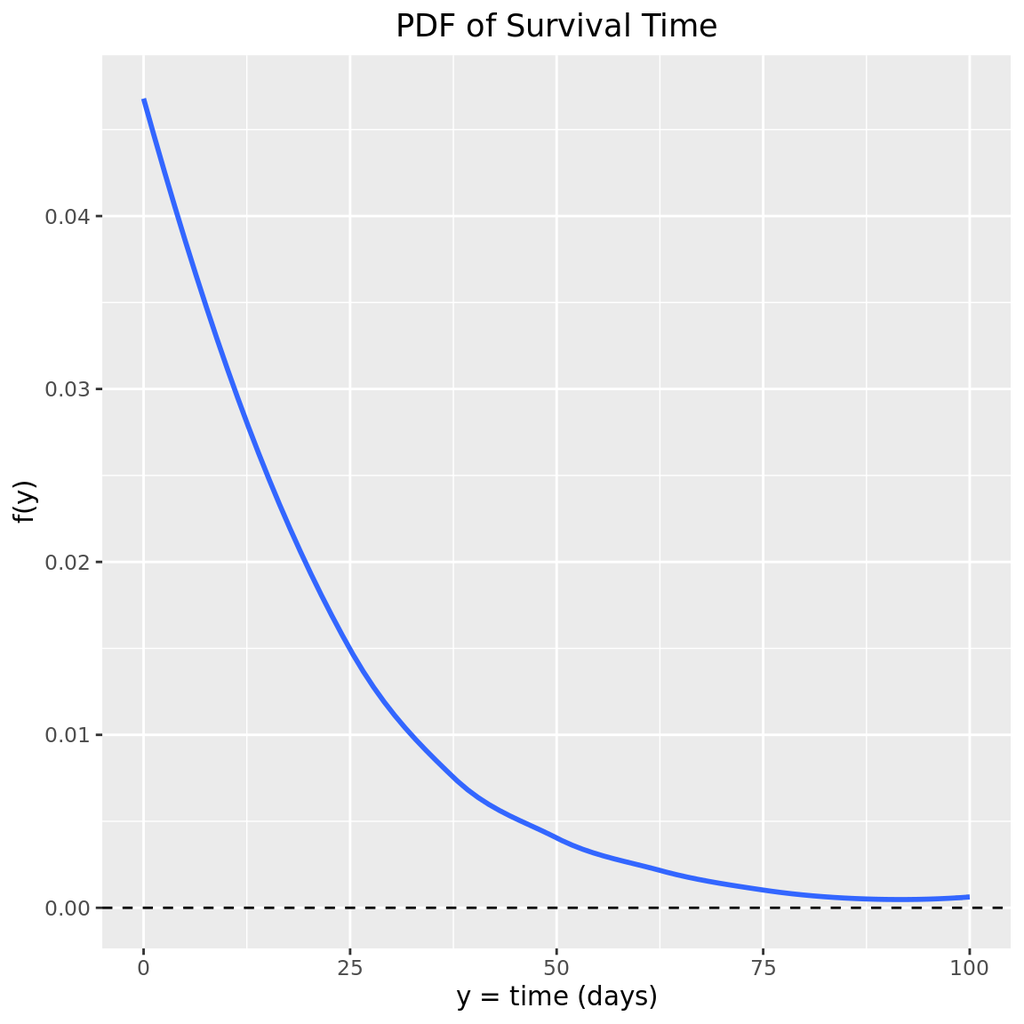

```r
yy <- seq(0, 100, by=0.1)             # sample space
fy <- function(y){ 1/20*exp(-y/20) }  # PDF
dat <- cbind(yy,fy(yy)) %>% as.data.frame()

a <- ggplot(dat, aes(x=yy,y=fy(yy)))+
  geom_smooth(method="loess",se=TRUE, fullrange=FALSE, level=0.95,formula = 'y ~ x')+
  labs(title = "PDF of Survival Time") +
  xlab("y = time (days)") + ylab("f(y)")+
  theme(plot.title = element_text(hjust = 0.5))+
  geom_hline(yintercept = 0,linetype="dashed")
a
```

(First, are the properties of a PDF met?)

```r
integrate(f=fy, lower=0, upper=Inf)  # check that it integrates to 1? Yes
# ify <- function(y){ -exp(-y/20) }  # anti-derivative (closed form)
# ify(Inf)-ify(0)                    # another way to check
```

Let A = {The person will survive less than 5 days}.

$P(A) = P(Y\le 5)= \int_0^5 (1/20)e^{-y/20}dy = 0.2212$

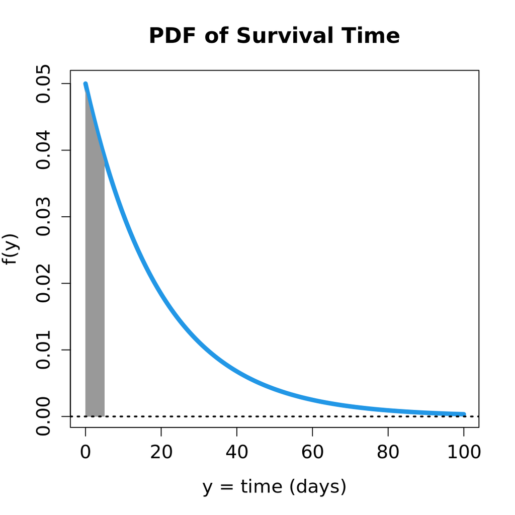

```r
integrate(f=fy, lower=0, upper=5)
# ify(5)-ify(0)

plot(yy, fy(yy), type="l", col=4, lwd=5, cex=1.3, cex.lab=1.3,
    cex.axis=1.3, cex.main=1.5, xlab="y = time (days)", ylab="f(y)",
    main="PDF of Survival Time")
  xcord <- c(0, seq(0, 5, 0.01), 5)
  ycord <- c(0, fy(seq(0, 5, 0.01)), 0)
  polygon(xcord, ycord, col="grey60", border=NA)
  lines(yy, fy(yy), col=4, lwd=3)
  abline(h=0, lwd=2, lty=3)
```

Let B = {The person will survive between 5 and 15 days}.

$P(B) = P(5\le Y\le 15) = \int_5^{15} (1/20)e^{-y/20}dy = 0.3064$

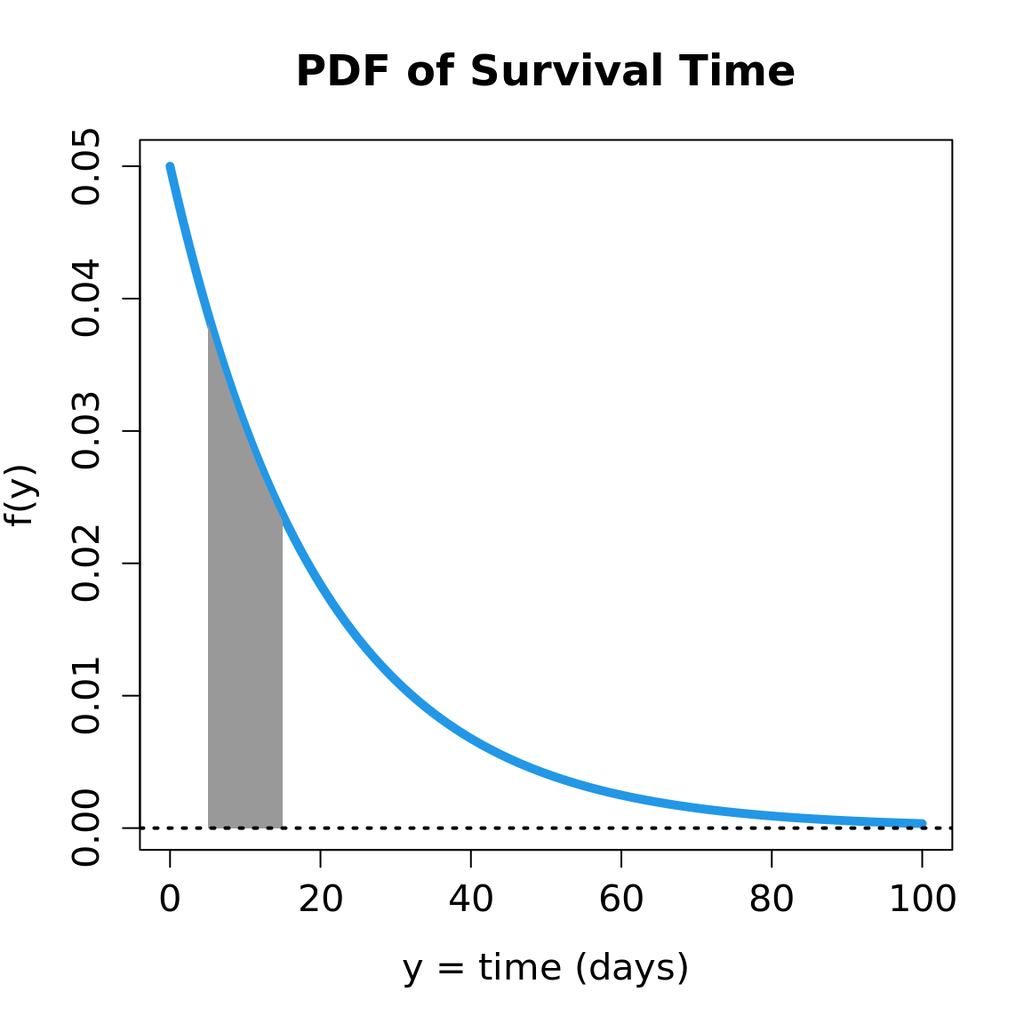

```r
integrate(f=fy, lower=5, upper=15)
# ify(15)-ify(5)

plot(yy, fy(yy), type="l", col=4, lwd=5, cex=1.3, cex.lab=1.3,
    cex.axis=1.3, cex.main=1.5, xlab="y = time (days)", ylab="f(y)",
    main="PDF of Survival Time")
  xcord <- c(5, seq(5, 15, 0.01), 15)
  ycord <- c(0, fy(seq(5, 15, 0.01)), 0)
  polygon(xcord, ycord, col="grey60", border=NA)
  lines(yy, fy(yy), col=4, lwd=3)
  abline(h=0, lwd=2, lty=3)
```

Let C={The person will survive at least 15 days}.

$P(C) = P(Y\ge 15) = \int_{15}^\infty (1/20)e^{-y/20}dy = 0.4724$

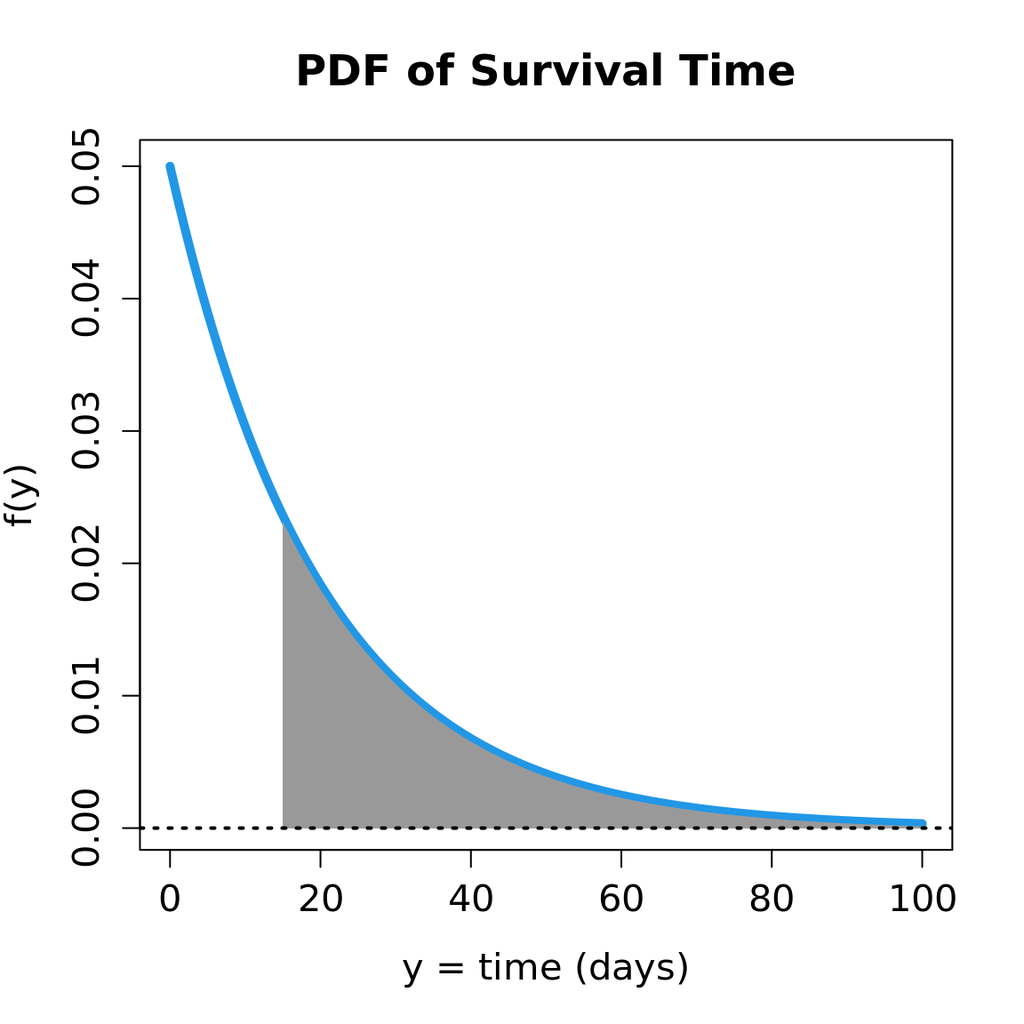

```r
integrate(f=fy, lower=15, upper=Inf)
# ify(Inf)-ify(15)

plot(yy, fy(yy), type="l", col=4, lwd=5, cex=1.3, cex.lab=1.3,
    cex.axis=1.3, cex.main=1.5, xlab="y = time (days)", ylab="f(y)",
    main="PDF of Survival Time")
  xcord <- c(15, seq(15, 100, 0.01), 100)
  ycord <- c(0, fy(seq(15, 100, 0.01)), 0)
  polygon(xcord, ycord, col="grey60", border=NA)
  lines(yy, fy(yy), col=4, lwd=3)
  abline(h=0, lwd=2, lty=3)
```

### Expectation and Variance

The **expected value** of $Y$ is the population mean, defined as

$$\mu = E(Y) = \int_{-\infty}^{\infty} yf(y)dy$$
The bounds of the integral are over all possible values of $Y$, not necessarily $(-\infty, \infty)$. The expectation represents the “average” value of $Y$.

The **variance** is a measure of the spread of all values around the expectation, defined as

$$\sigma^2 = \textrm{var}(Y) = \int_{-\infty}^{\infty} (y - \mu)^2f(y)dy = \int_{-\infty}^{\infty} y^2f(y)dy - \mu^2 = E(Y^2) - \{E(Y)\}^2$$
The **standard deviation** of Y is the positive square root of the variance, $\sigma$.

**Population**: Individuals who have acquired HIV-associated fungal infection

**Variable**: Survival time (in days) after acquiring infection

**Random sample**: One individual with the infection

**Random variable**: Y= Survival time (in days) after acquiring infection

$$f_Y(y) =\frac{1}{20}e^{-y/20}, 0 \le y \le \infty$$

$$E(X) = \int_{-\infty}^\infty yf(y) \; dy = \int_0^\infty y\left( \frac{1}{20}e^{-y/20} \right) dy$$

$$= -(y+20)e^{-y/20} |_0^\infty = 20$$
The average value of Y is 20 days.

```r
EYfun <- function(y){ y*(1/20*exp(-y/20)) }  # EY function
integrate(f=EYfun, lower=0, upper=Inf)
```

```
## 20 with absolute error < 0.00013
```

$$E(Y^2) = \int_{-\infty}^\infty y^2f(y) \; dy = \int_0^\infty y^2\left( \frac{1}{20}e^{-y/20} \right) dy$$
$$= - (y^2 + 40y + 800)e^{-y/20} |_0^\infty = 800$$

```r
EY2fun <- function(y){ y^2*(1/20*exp(-y/20)) }  # EY^2 function
integrate(f=EY2fun, lower=0, upper=Inf)
```

```
## 800 with absolute error < 3e-05
```

Thus:

$$\sigma^2 = \textrm{var}(Y) = E(Y^2) - (E(Y))^2 = 800 - (20)^2 = 400$$

```r
Varfun <- function(y){ (y-20)^2*(1/20*exp(-y/20)) }  # variance function
integrate(f=Varfun, lower=0, upper=Inf)
```

```
## 400 with absolute error < 3.9e-05
```

### Normal Distribution

Also known as the Gaussian distribution, it is the most widely used distribution in statistics.

The random variation of many clinical measurements taken are approximately normally distributed.

Examples in research studies include age, height, SBP, eGFR, lipids, and countless others.

In other words, it’s a good approximation of the distribution of many naturally occurring phenomena.

In addition, the **limiting distribution** of many common distributions (including discrete ones like the Binomial distribution) are normal. As some parameter of the distribution $\to \infty$, the distribution $\to$ Normal.

As n $\to \infty$, $Bin(n,\pi) \to N(\mu = n\pi, \sigma^2 = n\pi(1-\pi))$

**PDF for Normal with mean $\mu$ and variance $\sigma^2$**

$$f(y; \mu, \sigma^2) = \frac{1}{\sqrt{2\pi\sigma^2}} \exp \left\{ -\frac{1}{2} \left( \frac{y-\mu}{\sigma} \right)^2 \right\}$$

The expectation of $Y$ is $E(Y) = \mu$.

The variance of $Y$ is $var(Y) = \sigma^2$.

The notation $Y \sim N(\mu, \sigma^2)$ means $Y$ is normally distributed with mean $\mu$ and variance $\sigma^2$.

Bell-shaped and symmetric about $\mu$; two parameters describe it completely ($\mu$ and $\sigma^2$):

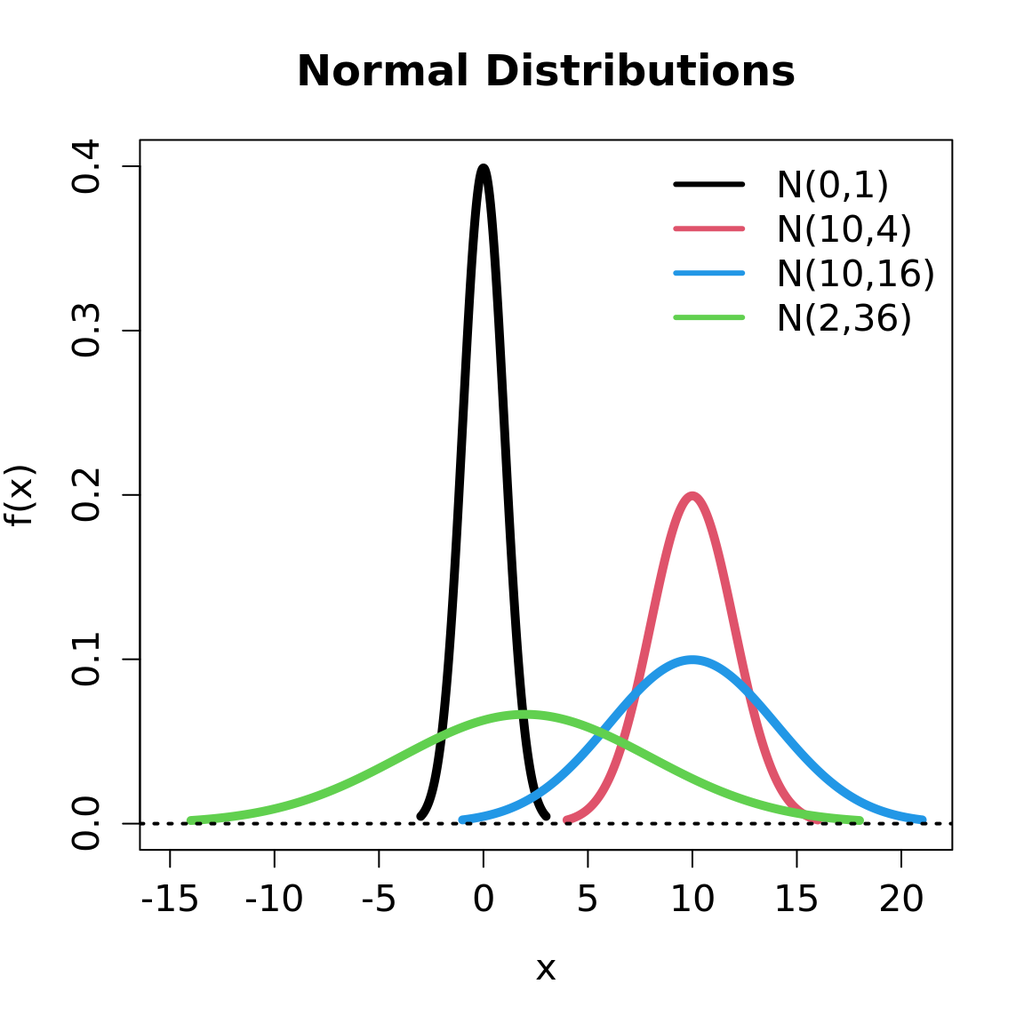

```r
# Note. This is one case where base R is much easier to use than ggplot2.

Y1 <- seq(-3,3, l=1000)
Y2 <- seq(4,16, l=1000)
Y3 <- seq(-1,21, l=1000)
Y4 <- seq(-14,18, l=1000)

plot(Y1, dnorm(Y1), type="l", lwd=5, cex=1.3, cex.lab=1.3, cex.axis=1.3,
    cex.main=1.5, xlim=c(-15,21), ylim=c(0,0.4), xlab="x", ylab="f(x)",
    main="Normal Distributions")
  lines(Y2, dnorm(Y2,10,2), col=2, lwd=5)
  lines(Y3, dnorm(Y3,10,4), col=4, lwd=5)
  lines(Y4, dnorm(Y4,2,6), col=3, lwd=5)
  abline(h=0, lwd=2, lty=3)
  legend("topright", legend=c("N(0,1)", "N(10,4)", "N(10,16)", "N(2,36)"),
      col=c(1:2,4:3), lwd=3, bty="n", cex=1.3)
```

**Standard Normal Distribution**

The **standard normal** distribution is a special case with $\mu = 0$ and $\sigma^2 = 1$. The PDF is

$$\phi(z) = \frac{1}{\sqrt{2\pi}}\exp \left(-\frac{1}{2}z^2 \right)$$

Standard normal random variables are typically denoted by $Z$. $\phi$ is typically used to denote the standard normal PDF, rather than $f_Z (z)$.

### Normal Distribution in R

Note that distributions in R have corresponding density (“d”), distribution (“p”), quantile (“q”), and random number generation (“r”) functions.

Let $Y \sim N(\mu = \textrm{mean}, \; \sigma^2 = (\textrm{sd})^2)$.

`dnorm(x, mean, sd, log=FALSE)` = height of the normal density at $x$

`pnorm(q, mean, sd, lower.tail = TRUE, log.p = FALSE)` = $P(Y \le q)$

`qnorm(p, mean, sd, lower.tail = TRUE, log.p = FALSE)` = $q_p$ such that $P(Y \le q_p) = p$

`rnorm(p, mean=0, sd=1)` will generate a sample of size n from a $N(\textrm{mean}, (\textrm{sd})^2)$.

`dnorm(x=-1, mean=0, sd=1, log=FALSE)` = 0.2419707

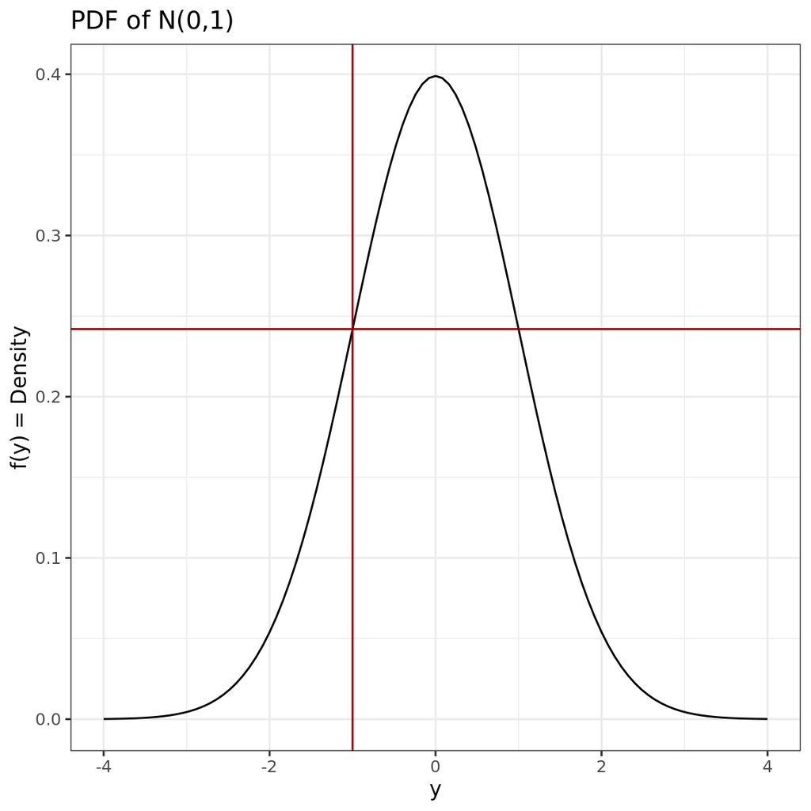

```r
y_value1 = dnorm(x=-1, mean=0, sd=1, log=FALSE)

ggplot(data.frame(y = c(-4, 4)), aes(y)) +
  stat_function(fun = dnorm, args=list(mean= 0, sd=1)) +
  geom_vline(xintercept = -1, color="darkred") +
  geom_hline(yintercept = y_value1, color="darkred") +
  labs(title="PDF of N(0,1)",
       y="f(y) = Density") +
  theme_bw()
```

`pnorm(q=-1, mean=0, sd=1, lower.tail = TRUE, log.p = FALSE)` = 0.1586553

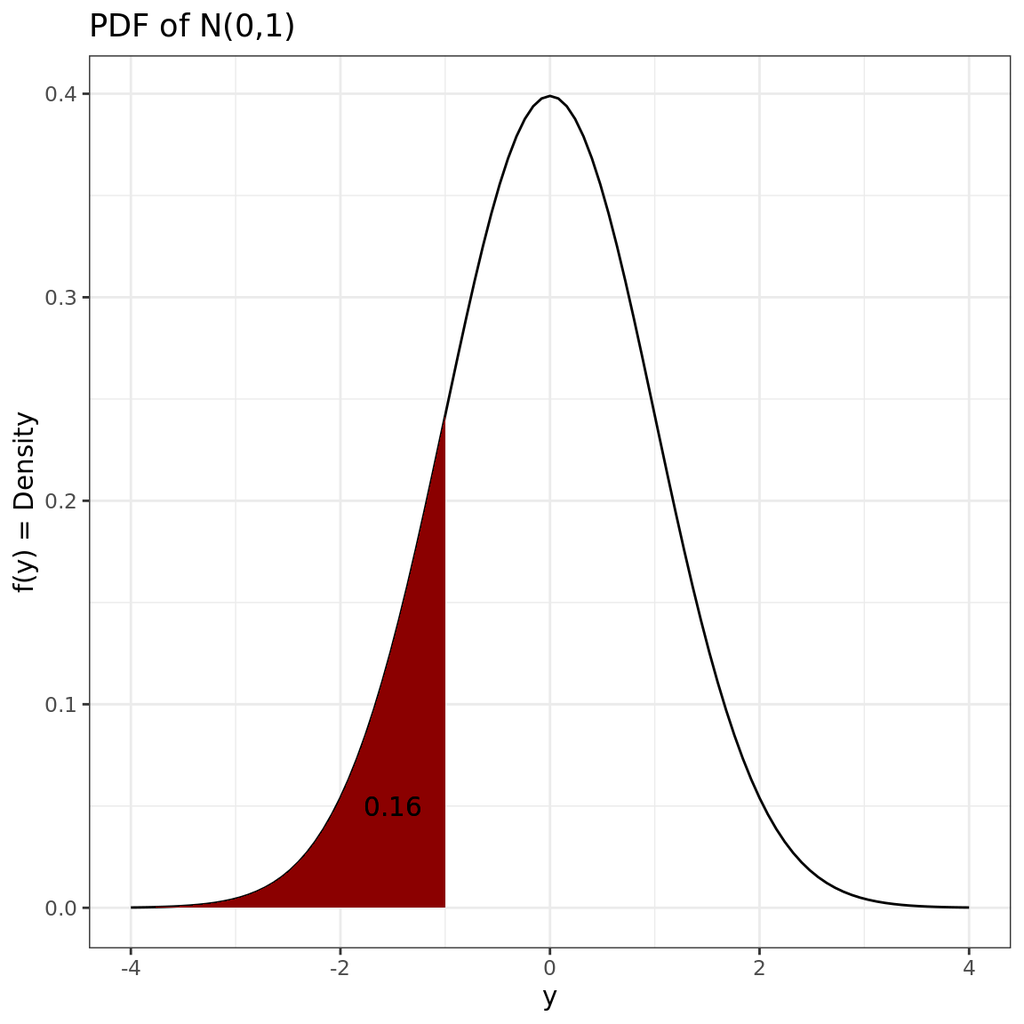

```r
ggplot(data.frame(y = c(-4, 4)), aes(y)) +
  stat_function(fun = dnorm, args=list(mean= 0, sd=1)) +
  stat_function(fun = dnorm,
                args=list(mean= 0, sd=1),
                xlim = c(-1,-4),
                geom = "area",
                fill="darkred") +
  geom_text(x=-1.5, y=0.05, label = "0.16") +
  labs(title="PDF of N(0,1)",
       y="f(y) = Density") +
  theme_bw()
```

`qnorm(p=0.16, mean=0, sd=1, lower.tail = TRUE, log.p = FALSE)` = -0.9944579

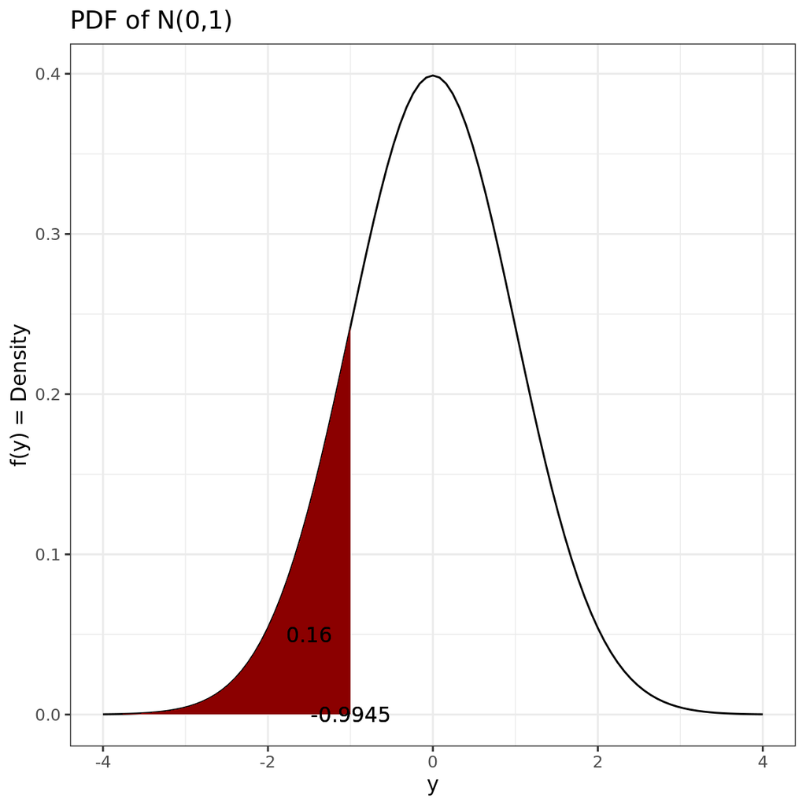

```r
ggplot(data.frame(y = c(-4, 4)), aes(y)) +
  stat_function(fun = dnorm, args=list(mean= 0, sd=1)) +
  stat_function(fun = dnorm,
                args=list(mean= 0, sd=1),
                xlim = c(-1,-4),
                geom = "area",
                fill="darkred") +
  geom_text(x=-1.5, y=0.05, label = "0.16") +
  geom_text(x=-0.9945, y=0, label= "-0.9945") +
  labs(title="PDF of N(0,1)",
       y="f(y) = Density") +
  theme_bw()
```

# Exercises: Probability and Distributions

## Question 1: PMF

The PMF example of babies born with type O blood is actually a binomial random variable. The number of trials is $n=4$, and the probability of an event (type O blood) is $\pi=0.44$. That is, $Y \sim \textrm{Bin}(4,0.44)$.

Redo the events using the `binom` functions.

Let A={All four babies have type O blood}. P(A)=?

```r
# [type answer here]
```

Let B={At least two babies have type O blood}. P(B)=?

```r
# [type answer here]
```

Let C={Between 1 and 3 babies have type O blood}. P(C)=?

```r
# [type answer here]
```

Compute $E(Y)$, $E(Y^2)$, and var$(Y)$ using the `binom` functions.

```r
# [type answer here]
```

## Question 2: PDF

The PDF example of survival is actually an exponential random variable $Y \sim Exp(\lambda = 1/20)$. Redo the following using the `pexp` function.

Let A={The person will survive less than 5 days}. P(A)=?

```r
# [type answer here]
```

Let B={The person will survive between 5 and 15 days}. P(B)=?

```r
# [type answer here]
```

Let C={The person will survive at least 15 days}. P(C)=?

```r
# [type answer here]
```

## Question 3: Q-Q Plots for Checking Normality

Plots can help determine if certain distributional assumptions are reasonable.

The normal distribution is one of the most common distributions assumed.

Plotting the **sample quantiles** against what would be expected for a normal distribution can help make that determination. This plot is called a Q-Q plot (quantile-quantile plot).

- Plot **quantiles of the observed data** distribution versus the **quantiles of the theoretical normal distribution**.
- Straight line indicates normality assumption is reasonable.
- In R, see `?qqnorm` to create the plot and `?qqline` to add the line
1. Generate 1000 random values from a $N(10,4)$. Create a Q-Q plot and add a line to check normality.

```r
# [type answer here]
```

2. Generate 1000 random values from an Exp$(1/20)$. Create a Q-Q plot and add a line to check normality.

```r
# [type answer here]
```

3. Comment on the differences between the two plots.

```r
# [type answer here]
```

Note that Q-Q plots are commonly used to check normality, but the methods described can be used to check **any distribution**.

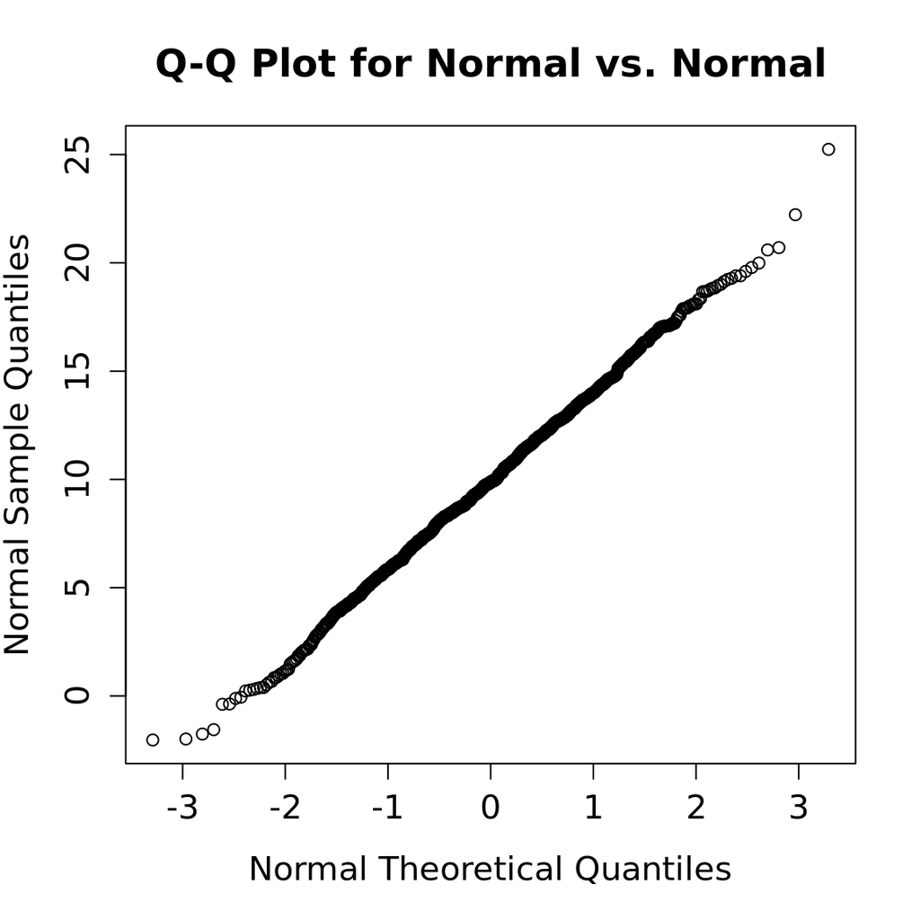

```r
set.seed(1)
Xnorm <- sort(rnorm(1000, mean=10, sd=4))  # normal data
Xexp  <- sort(rexp(n=1000, rate=1/20))     # non-normal data

Xnormt <- qnorm(ppoints(length(Xnorm)))    # theoretical quantiles
Xexpt  <- qexp(ppoints(length(Xnorm)), rate=1/20)

# Check that normal data comes from normal distribution
plot(Xnormt, Xnorm, main="Q-Q Plot for Normal vs. Normal", cex.lab=1.3,
    cex.axis=1.3, cex.main=1.5, xlab="Normal Theoretical Quantiles",
    ylab="Normal Sample Quantiles")
```

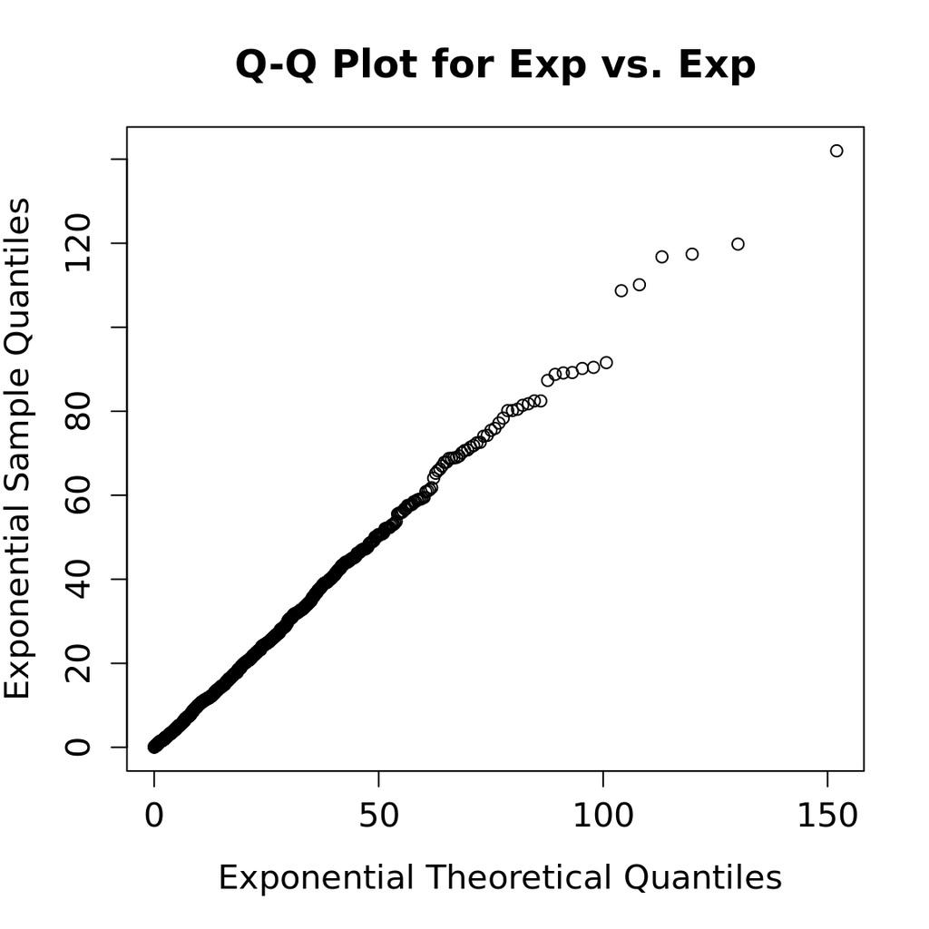

```r
# Check that exponential data comes from exponential distribution
plot(Xexpt, Xexp, main="Q-Q Plot for Exp vs. Exp", cex.lab=1.3,
    cex.axis=1.3, cex.main=1.5, xlab=" Exponential Theoretical Quantiles",
    ylab="Exponential Sample Quantiles")
```

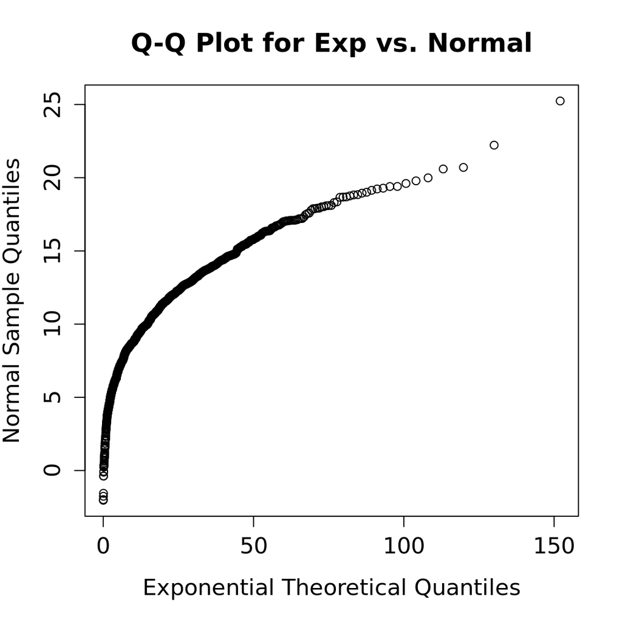

```r
# Check that normal data comes from exponential distribution
plot(Xexpt, Xnorm, main="Q-Q Plot for Exp vs. Normal", cex.lab=1.3,
    cex.axis=1.3, cex.main=1.5, xlab="Exponential Theoretical Quantiles",
    ylab="Normal Sample Quantiles")
```

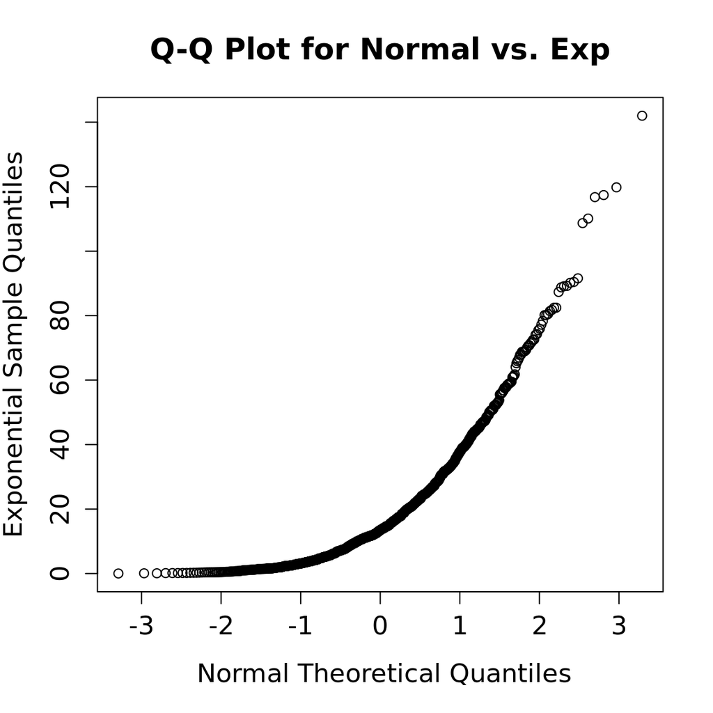

```r
# Check that exponential data comes from normal distribution
plot(Xnormt, Xexp, main="Q-Q Plot for Normal vs. Exp", cex.lab=1.3,
    cex.axis=1.3, cex.main=1.5, xlab=" Normal Theoretical Quantiles",
    ylab="Exponential Sample Quantiles")
```

# Parameters, Statistics, and Sampling Distributions

## Definitions

A **sample statistic** is any value computed or determined from the data in a sample:

**mean, median, standard deviation, maximum, IQR, etc.**

Statistics have population analogues, called **parameters**.

We generally want to draw conclusions about population parameters using statistics computed from a sample.

### Case #1

A researcher wants to know the mean change in LDL among a target population – i.e. the *population mean*. He samples $n=300$ individuals, measures their change in LDL and calculates the *sample mean*. He uses the sample mean to draw inference on the mean proportion.

### Case #2

A researcher wants to know prevalence of virologic control among a target population – i.e. the *population proportion*. He samples $n=320$ individuals and counts how many have virologic control over follow-up, the *sample proportion*. He uses the sample proportion to draw inference on the population proportion.

### Population Mean

The population mean is the “expected value” of a random variable, $Y$, typically denoted as $\mu$. That is, $\mu=E(Y)$.

The mean, $\mu$ can be thought of as what we would expect the value of one realization of the random variable to be. It’s the average value of $Y$.

### Population Variance

The variance is a measure of spread of the distribution around the population mean, typically denoted as $\sigma^2$. That is, $\sigma^2=\textrm{var}(Y)$.

The population standard deviation, $\sigma$, is the square root of the variance.

### Population Percentiles

Similar to sample percentiles, the $(100\times p)$th percentile - denoted $\zeta_p$ - of a random variable is the value of the random variable that is less than or equal to $\zeta_p, (100\times p)$ percent of the time.

### Statistics Are Random Variables

- Any value computed or derived from a sample is a sample statistic.
- A different sample will yield a different value of the statistic.
- Therefore, multiple samples of the population would yield multiple values of the statistic.
- Because of the randomness of the sample that generates the statistic, the statistic itself is a **random variable**.
- Observing the numeric value of a statistic is considered one possible value of all possible values that statistic could take with repeated samples (of size $n$) from that population.
- Random variables have probability distributions (PMFs and PDFs).
- Statistics are random variables.
- Statistics have probability distributions.

## Sampling Distribution of a Statistic

The PMF/PDF of a statistic from a sample of size n is call the **sampling distribution** of that statistic. This distribution describes **how the statistic varies from sample to sample**.

- Let $Y_1,Y_2,...,Y_n$ be a random sample from some distribution, $f_Y (\cdot)$ of interest.
- Each $Y_i$ has the same population distribution $f_Y (\cdot)$ with a set of parameters (e.g., $\mu$, $\sigma^2$, etc.).
- Any statistic created from the sample (e.g., $\bar{Y}, S^2$, etc.) also has a probability distribution, e.g. $f_\bar{Y}(\cdot)$. Note that $f_Y\ne f_\bar{Y}$ . This is the sampling distribution.

The PDF of the random variable $\bar{Y}$ is the **sampling distribution of the mean**.

The PDF of the random variable $S^2$ is the **sampling distribution of the variance**.

The PDF for the random variable $M$ is the **sampling distribution of the median**.

### Standard Error

The standard deviation of a sampling distribution is called the **standard error**.

### Distinction

The standard deviation is a general measure of spread about the mean - of a sample or a population, for example.

The standard error is a specific measure of spread about the mean - how values of a **statistic** vary about the mean value. The standard error is the standard deviation of a statistic.

The standard deviation of the random variable $\bar{Y}$ is the **standard error of the mean**.

The standard deviation of the random variable $S^2$ is the **standard error of the variance**.

The standard deviation for the random variable $S$ is the **standard error of the standard deviation**.

## Sampling Distribution of the Sample Mean

- Let a random variable Y have a specified probability distribution with **population mean $\mu$ and population variance $\sigma^2$**. In symbols, $Y\sim f_Y (y;\mu,\sigma^2 )$.
- From the distribution $f_Y (y;\mu,\sigma^2 )$, take a random sample $Y_1,Y_2,...,Y_n$. The $Y_i$’s are independent of each other, and all have the same distribution, $f_Y$. $Y_1,Y_2,...,Y_n \sim$ iid $f_Y (y;\mu; \sigma^2)$.

Case #1: Suppose the random variable of interest $Y$ is change in LDL (a continuous variable). From the target population, $Y$ follows some (unknown) distribution that has mean $\mu$ and variance $\sigma^2$. Randomly sample $n$ individuals and measure change in LDL of each: $Y_1,Y_2,\ldots,Y_n$. This is a random sample of $Y$. The $Y_i$’s are independent of each other, and they all follow the same distribution.

Case #2: Suppose the random variable of interest $Y$ is virologic control, defined as HIV RNA < 50 copies/mL (a binary variable). From the target population, $Y$ follows some distribution (Bernoulli) that has mean $\mu$ ($=\pi$) and variance $\sigma^2$ ($=\pi (1-\pi)$). Randomly sample $n$ patients and determine if each has virologic control: $Y_1,Y_2,\ldots,Y_n$. This is a random sample of $Y$. The $Y_i$’s are independent of each other, and they all follow the same distribution (Bernoulli).

- Compute the sample mean, $\bar{Y}$.
- Then $\bar{Y}$ has a sampling distribution $f_\bar{Y}(\cdot)$ with population mean $\mu$, and population variance $\sigma^2/n$.
- Note: $f_\bar{Y}(\cdot)$ could be the same as $f_Y (\cdot)$, or it could be different. Regardless, the mean of $f_\bar{Y}$ is $\mu$ and the variance is $\sigma^2/n$.

Case #1: The sample mean change in LDL has a sampling distribution $f_\bar{Y}(\cdot)$ with population mean $\mu$, and population variance $\sigma^2/n$.

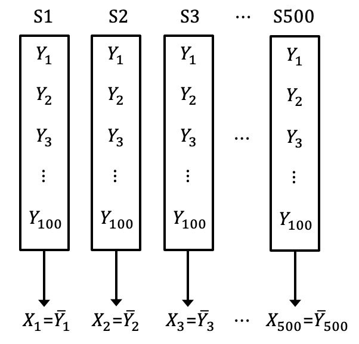

Each sample, S1, S2,…,S500 follows some distribution with mean $\mu$ and variance $\sigma^2$.

Take the mean of each sample, $X_1,X_2,...,X_{500}$. This is *also* a random sample.

The mean and variance of the random sample of $X's$ are

$$\bar{X}=\frac{1}{500}\sum_{i=1}^{500}X_i \approx \mu$$
$$S_X^2=\frac{1}{500-1}\sum_{i=1}^{500}(X_i-\bar{X})^2 \approx \frac{\sigma^2}{n}$$

## Normal Population and the Central Limit Theorem

In general, the distribution of the random sample and the sampling distribution of the mean is not necessarily the same.

BUT! Suppose $Y_1,Y_2,...,Y_n \sim$ iid $N(\mu,\sigma^2)$. Then $\bar{Y} \sim N(\mu,\sigma^2/n)$.

In other words, if the distribution of the underlying population of the random sample is normal, then **the sampling distribution of the sample mean is also normal**.

Check it out! Create a Q-Q plot of the vector in problem (2) of the Exercise below.

Even when distribution of the random sample is **not normal**, the CLT says that the **sampling distribution of the mean is approximately normal** for “large enough $n$”.

More formally:

Let $Y_1,Y_2,\ldots,Y_n$ be a random sample from **any distribution**, with mean $E(Y_i)=\mu$ and variance var$(Y_i)=\sigma^2>0$. Then $\bar{Y} \sim N(\mu,\sigma^2/n)$ for sufficiently large $n$.

**In words**: If a random variable $Y$ has population mean $\mu$ and non-zero variance $\sigma^2$, then the sample mean $\bar{Y}$, based on $n$ observations, is **approximately normally distributed** with mean $\mu$ and variance $\sigma^2/n$ for sufficiently large $n$.

Check it out! Create a Q-Q plot of the vector in problem (2) below with means from the Bernoulli population.

**Example Population Distributions**

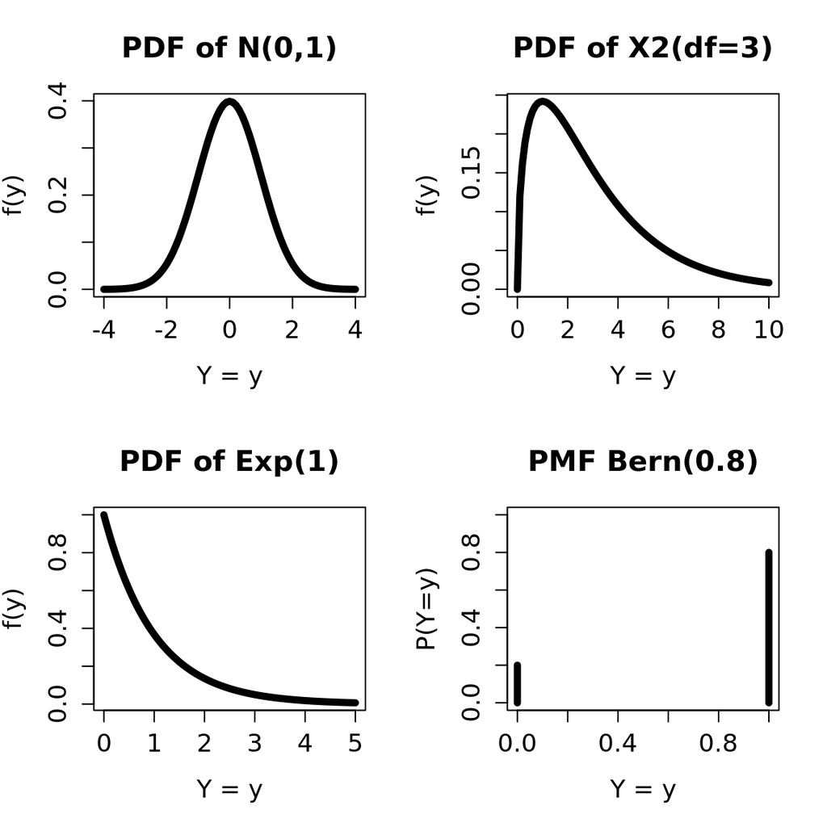

```r
par(mfrow=c(2,2))
#----------------------  First plot pop distributions  ---------------------#
plot(seq(-4, 4, 0.1), dnorm(seq(-4, 4, 0.1)), type="l", lwd=5, cex=1.3,
    cex.lab=1.3, cex.axis=1.3, cex.main=1.5, xlab="Y = y", ylab="f(y)",
    main="PDF of N(0,1)")

plot(seq(0,10, l=101), dchisq(seq(0,10, l=101), df=3), type="l", lwd=5,
    cex=1.3, cex.lab=1.3, cex.axis=1.3, cex.main=1.5, xlab="Y = y",
    ylab="f(y)", main="PDF of X2(df=3)")

plot(seq(0,5, l=101), dexp(seq(0,5, l=101)), type="l", lwd=5,
    cex=1.3, cex.lab=1.3, cex.axis=1.3, cex.main=1.5, xlab="Y = y",
    ylab="f(y)", main="PDF of Exp(1)")

plot(0:1, dbinom(0:1,1,0.8), type="h", lwd=5, cex=1.3, cex.lab=1.3,
    cex.axis=1.3, cex.main=1.5, xlab="Y = y", ylab="P(Y=y)", ylim=c(0,1),
    main="PMF Bern(0.8)")
```

**Estimated Sampling Distributions of $\bar{Y}$**

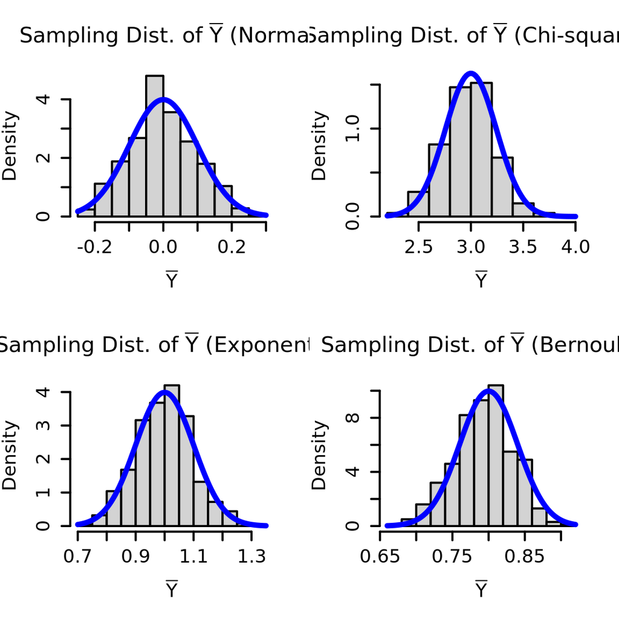

```r
#--------------------  Estimate Sampling distributions  --------------------#
NN <- 500  # number of replicates, NOT the sample size!
nn <- 100  # sample size n = 100
set.seed(1)

# Normal(0, 1)
Y_norm <- matrix(rnorm(nn*NN), nrow=100)          # N(0,1)
Yb_norm <- sort(colMeans(Y_norm))

# Chi-squared(df=3)
Y_x2 <- matrix(rchisq(nn*NN, df=3), nrow=100)     # X2(df=3)
Yb_x2 <- sort(colMeans(Y_x2))

# Exponential(1)
Y_exp <- matrix(rexp(nn*NN, rate=1), nrow=100)    # exp(1)
Yb_exp <- sort(colMeans(Y_exp))

# Bernoulli(0.8)
Y_bin <- matrix(rbinom(nn*NN, 1, 0.8), nrow=100)  # Bern(0.8)
Yb_bin <- sort(colMeans(Y_bin))

Theoretical <- qnorm(ppoints(NN))  # theoretical quantiles of N(0,1)

par(mfrow=c(2,2))
#----------------------  Plot Sampling distributions  ----------------------#
par(lwd=2)
hist(Yb_norm, lwd=2, cex=1.3, cex.lab=1.3, cex.axis=1.3, cex.main=1.5,
    xlab=expression(bar(Y)), freq=FALSE,
    main=expression("Sampling Dist. of "*bar(Y)*" (Normal)"))
  #lines(density(Yb_norm), col="red", lwd=5)
  curve(dnorm(x, mean=0, sd=sqrt(1/100)), add=TRUE, col="blue", lwd=5)

par(lwd=2)
hist(Yb_x2, lwd=2, cex=1.3, cex.lab=1.3, cex.axis=1.3, cex.main=1.5,
    xlab=expression(bar(Y)), freq=FALSE, ylim=c(0,1.6),
    main=expression("Sampling Dist. of "*bar(Y)*" (Chi-squared)"))
  #lines(density(Yb_x2), col="red", lwd=5)
  curve(dnorm(x, mean=3, sd=sqrt(6/100)), add=TRUE, col="blue", lwd=5)

par(lwd=2)
hist(Yb_exp, lwd=2, cex=1.3, cex.lab=1.3, cex.axis=1.3, cex.main=1.5,
    xlab=expression(bar(Y)), freq=FALSE,
    main=expression("Sampling Dist. of "*bar(Y)*" (Exponential)"))
  #lines(density(Yb_exp), col="red", lwd=5)
  curve(dnorm(x, mean=1, sd=sqrt(1/100)), add=TRUE, col="blue", lwd=5)

par(lwd=2)
hist(Yb_bin, lwd=2, cex=1.3, cex.lab=1.3, cex.axis=1.3, cex.main=1.5,
    xlab=expression(bar(Y)), freq=FALSE,
    main=expression("Sampling Dist. of "*bar(Y)*" (Bernoulli)"))
  #lines(density(Yb_bin), col="red", lwd=5)
  curve(dnorm(x, mean=0.8, sd=sqrt(0.8*0.2/100)), add=TRUE, col="blue", lwd=5)
```

**QQ Plots of Sampling Distribution of $\bar{Y}$**

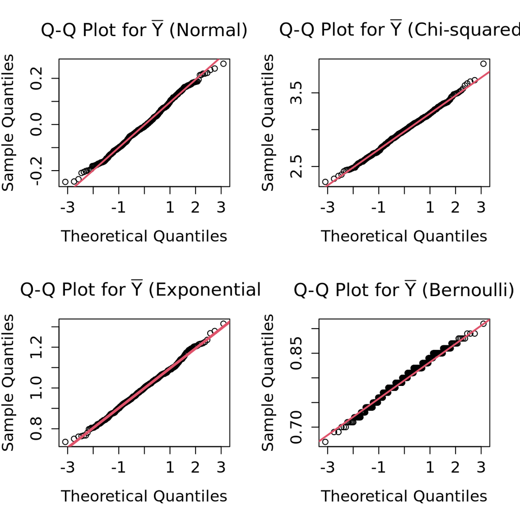

```r
par(mfrow=c(2,2))
#-------------------------  QQ Plot of Samp dists  -------------------------#
# qqnorm(Yb_norm)
plot(Theoretical, Yb_norm, cex.lab=1.3, cex.axis=1.3, cex.main=1.5,
    main=expression("Q-Q Plot for "*bar(Y)*" (Normal)"),
    xlab="Theoretical Quantiles", ylab="Sample Quantiles")
    qqline(Yb_norm, lwd=2, col=2)

plot(Theoretical, Yb_x2, cex.lab=1.3, cex.axis=1.3, cex.main=1.5,
    main=expression("Q-Q Plot for "*bar(Y)*" (Chi-squared)"),
    xlab="Theoretical Quantiles", ylab="Sample Quantiles")
    qqline(Yb_x2, lwd=2, col=2)

plot(Theoretical, Yb_exp, cex.lab=1.3, cex.axis=1.3, cex.main=1.5,
    main=expression("Q-Q Plot for "*bar(Y)*" (Exponential)"),
    xlab="Theoretical Quantiles", ylab="Sample Quantiles")
    qqline(Yb_exp,lwd=3, col=2)

plot(Theoretical, Yb_bin, cex.lab=1.3, cex.axis=1.3, cex.main=1.5,
    main=expression("Q-Q Plot for "*bar(Y)*" (Bernoulli)"),
    xlab="Theoretical Quantiles", ylab="Sample Quantiles")
    qqline(Yb_bin, lwd=2, col=2)
```

```r
#===========================================================================#
```

### What is considered “sufficiently large”?

A common question is “how large does n have to be?” The answer…it depends. How “non-normal” is the underlying population distribution?

- Discrete population distributions or those highly skewed will need larger sample sizes for the CLT approximation to hold.
- Continuous, symmetric, “bell-shaped” distributions don’t need as large of a sample size.
- Some use a rule of thumb of $n\ge 30$ to apply the CLT. DON’T DO THIS.
- 30 may not be enough for skewed distributions; 30 may be too much for “almost normal” distributions.

Instead of using rules of thumb or generic guidelines, **know the data** and assumptions, make plots, compute descriptive statistics, run simulations, etc. and make a decision on a case-by-case basis.

# Exercise: Sampling Distributions

1. Create a matrix of size $100\times 500$ of data generated from a normal distribution with some mean $\mu$ and some variance, $\sigma^2$ (you are free to choose whatever values you want, or simply use $\mu=0$ and $\sigma^2=1$).

You can use the function `?rnorm`, and be sure to set a seed. This matrix will represent 500 resamples from a target population. Thus, each column is a sample of size $n=100$.

```r
set.seed(2894)
# [type answer here]
```

2. Compute the mean of each sample (i.e., each column) and store this in a vector.

The resulting vector should have length 500.

```r
# [type answer here]
```

3. Now, compute the mean and variance of the vector in (2).

The mean should be very close to the $\mu$ you specified. The variance should be very close to $\sigma^2/100$.

```r
# [type answer here]
```

4. Repeat (1) - (3) with data from a Bernoulli distribution.

You can use `?rbinom` with `size=1` and `prob=` any $\pi$ you want (e.g., $\pi=0.4$). The mean in (3) should be $\approx \pi$ and the variance $\approx \pi(1-\pi)/100$.

```r
# [type answer here]
```

# Confidence Intervals

## A $100(1-\alpha)\%$ Confidence Interval for $\mu$

- Suppose a population is $N(\mu,\sigma^2)$ and interest lies in estimating the population mean, $\mu$.
- If a sample $Y_1,Y_2,\ldots,Y_n$ is drawn from the population, then the sample mean $\bar{Y}$ is the “best” **point estimator** for $\mu$.
- However, because $\bar{Y}$ is a random variable, it is highly unlikely that the estimate $\bar{Y}$ will be exactly equal to $\mu$.
- With a point estimate alone, there is no sense of how far off the realization $\bar{y}$ is from $\mu$. Thus it’s preferable to estimate $\mu$ with a range of plausible values, rather than a single number.

**Point estimate**: A meteorologist estimates that it will rain at 3pm.

**Interval estimate**: A meteorologist estimates that it will rain at 3pm, but it’s possible that it will rain anywhere for 1pm to 5pm.

Suppose a random sample $Y_1,Y_2,\ldots,Y_n\sim N(\mu,\sigma^2)$ with unknown mean and variance. Skipping the theory, a $100(1-\alpha)\%$ CI for $\mu$ is defined as
$$\bar{y}\pm t_{n-1,1-\alpha/2}\frac{s}{\sqrt{n}} \Rightarrow (\bar{y}-t_{n-1,1-\alpha/2}\frac{s}{\sqrt{n}}, \; \;\bar{y}+t_{n-1,1-\alpha/2} \frac{s}{\sqrt{n}})$$

- $\bar{y}$ is the realization of the sample mean
- $s$ is the realization of the sample standard deviation
- $n$ is the sample size
- $t_{n-1,1-\alpha/2}$ is the $(1-\alpha/2)$th quantile of a $t$ distribution with $n-1$ degrees of freedom
- $t_{n-1,1-\alpha/2}$ can be computed from `qt(p=1-a/2, df=n-1, lower.tail=TRUE, log.p=FALSE)`

### The t Distribution

- The central $t$ distribution has one parameter $\nu$, called the degrees of freedom.
- The sample space is $-\infty <y<\infty$
- It is related to a normal distribution
- See `dt, pt, qt,` and `rt` functions

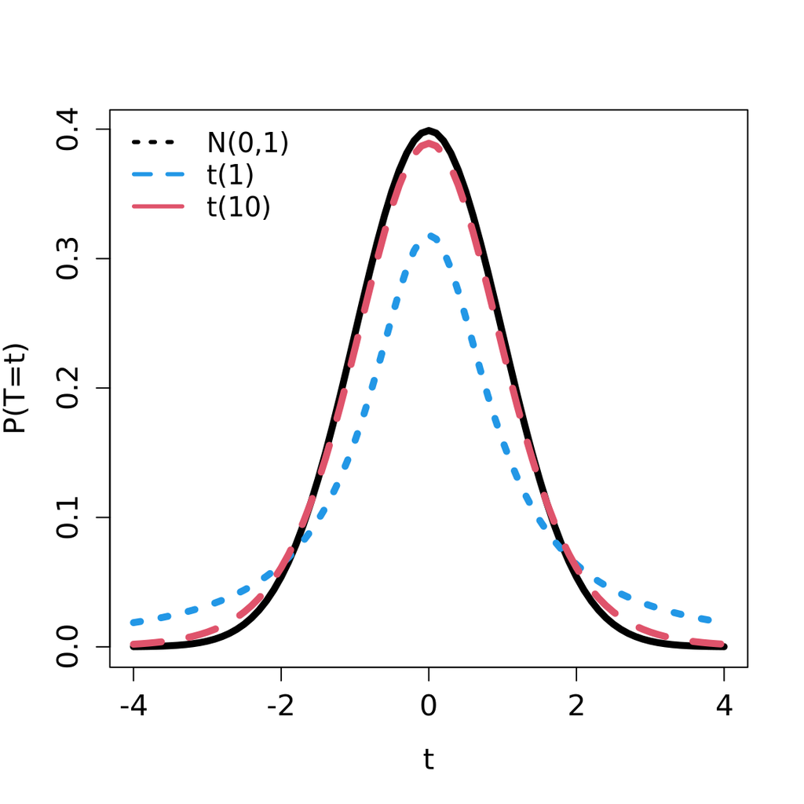

```r
zz <- seq(-4, 4, 0.1)
plot(zz, dnorm(zz), type="l", lwd=5, cex=1.3, cex.lab=1.3, cex.axis=1.3,
    cex.main=1.5, xlab="t", ylab="P(T=t)")
  lines(zz, dt(zz, df=1), lwd=5, lty=3, col=4)
  lines(zz, dt(zz, df=10), lwd=5, lty=2, col=2)
  legend("topleft", c("N(0,1)", "t(1)", "t(10)"), lwd=3, lty=3:1, cex=1.2,
      col=c(1,4,2),  bty="n")
```

### Example: Confidence Interval for Population Mean $\mu$

Case #1: Compute a $90\%$, $95\%$, and $99\%$ confidence interval for the population mean change in LDL from week 0 to week 24 among the target population.

```r
YY <- na.omit(Case1LDL$LDLchg)
yb <- mean(YY);  s <- sd(YY);  n <- length(YY)  # sample statistics
yb  # sample mean
s   # sample standard deviation
```

[output not shown]

$90\%$ CI for the unknown population mean $\mu$
$$\bar{y} \pm t_{n-1, 1-\alpha/2} \frac{s}{\sqrt{n}} \Rightarrow 2.227 \pm 1.651 \left( \frac{25.474}{262} \right) \Rightarrow (-0.37, 4.83)$$

```r
# 90 % CI
# t.test(x=YY, alternative="two.sided", mu=0, conf.level=0.90)
tcrit <- qt(0.95, df=n-1)
yb + c(-tcrit*s/sqrt(n), tcrit*s/sqrt(n))
```

```
## [1] -0.3703777  4.8253395
```

$95\%$ CI
$$\bar{y} \pm t_{n-1, 1-\alpha/2} \frac{s}{\sqrt{n}} \Rightarrow 2.227 \pm 1.969 \left( \frac{25.474}{262} \right) \Rightarrow (-0.87, 5.33)$$

```r
# 95 % CI
# t.test(x=YY, alternative="two.sided", mu=0, conf.level=0.95)
tcrit <- qt(0.975, df=n-1)
yb + c(-tcrit*s/sqrt(n), tcrit*s/sqrt(n))
```

```
## [1] -0.8714409  5.3264028
```

$99\%$ CI
$$\bar{y} \pm t_{n-1, 1-\alpha/2} \frac{s}{\sqrt{n}} \Rightarrow 2.227 \pm 2.595 \left( \frac{25.474}{262} \right) \Rightarrow (-1.86, 6.31)$$

```r
# 99 % CI
# t.test(x=YY, alternative="two.sided", mu=0, conf.level=0.99)
tcrit <- qt(0.995, df=n-1)
yb + c(-tcrit*s/sqrt(n), tcrit*s/sqrt(n))
```

```
## [1] -1.856159  6.311121
```

Case #2: Compute a $90\%$, $95\%$, and $99\%$ confidence interval for the population mean HIV RNA among the target population using the baseline data. (Note that the mean RNA might not be a good measure of central location – why?)

```r
# [type answer here]
```

### Interpretation of Confidence Intervals

- The interval is being constructed around the estimated mean from a sample. Thus, **the interval will change** from sample to sample **because the estimated mean changes** from sample to sample.
- Most of the time, the interval constructed will contain the true population mean $\mu$.
- Rarely, if the sample taken generates one of the more extreme values of the sample mean, the interval will not contain $\mu$.
- In fact, **if we drew many samples**, computed $\bar{y}$, and constructed a CI in this manner for each sample, then **about $100(1-\alpha)%$ of the intervals will contain $\mu$**.

**Probabilistic Interpretation**

“In repeated sampling from a normally distributed population, $100(1-\alpha)\%$ of all intervals of the form $\bar{y}\pm t_{n-1,1-\alpha/2}\frac{s}{\sqrt{n}}$ will in the long run include the population mean $\mu$.”

**Common Practical Interpretation**

“When sampling is from a normally distributed population, we are $100(1-\alpha)\%$ confident that the single interval $\bar{y}\pm t_{n-1,1-\alpha/2}\frac{s}{\sqrt{n}}$ contains the population mean.”

**Caution in Interpretation**

The interpretation is NOT a probabilistic statement about the population mean! The true mean $\mu$ is a fixed value - it’s not a random variable so it does not have any probability distribution.

**This interpretation is WRONG: “There is a 95% chance (or probability) that the true population mean is between -0.87 and 5.33.”**

Once the interval is constructed, the true mean is either in the interval or it is not.

The CI is a statement about what is expected with repeated sampling. The probability in the interpretation is a measure of *how confident* we are that our specific interval contains the true mean; it’s not the probability of the mean being in the interval.

The *process* of repeated sampling is what gives the 95% chance that the particular interval created will contain the parameter.

**Case #1 Simulation**: Let change in LDL among the target population be normally distributed with $\mu=2$ and $\sigma=25$. If 80 different samples of size $n=300$ were drawn from this population and a 95% CI constructed from each sample, then about 76 (95%) are expected to contain $\mu$ (and 4 are expected not to).

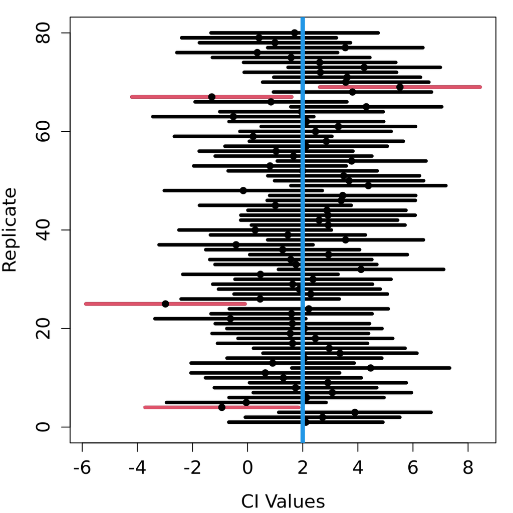

```r
set.seed(121)
Pop <- rnorm(50000, mean=2, sd=25 )  # Create hypothetical pop'n, N=50000
#hist(Pop, breaks=40, freq=F)
#  lines(density(Pop), col=4, lwd=3)
#  curve(dnorm(x, mean=2, sd=25), add=TRUE, col=2, lwd=3)

# take 80 samples, n=300
Samps <- replicate(80, sample(Pop, size=300, replace=FALSE))  # 320x80 matrix


#-----------------  Write a function that will compute CIs  ----------------#
CI <- function(x=NULL, a=0.05, mn, SD, n){
    if(!is.null(x)){  # if data entered, use sample values for CI
        mn <- mean(x, na.rm=TRUE); SD <- sd(x, na.rm=TRUE); n <- length(x)
    }
    tcrit <- qt(c(a/2, 1-a/2), df=n-1)  # critical values for CI
    CI <- mn + tcrit*SD/sqrt(n)
    rslt <- c(CI[1], mn, CI[2])
    return(rslt)
}                                            # test it out:   CI(Samps[,1])
#---------------------------------------------------------------------------#

allCIs <- apply(Samps, 2, CI)
out <- which(allCIs[1,] >2 | allCIs[3,] < 2)  # which don't contain mu?

# par(mar=c(5.1, 4.1, 4.1, 2.1))  # default margins
par(mar=c(4.1, 4.1, 1, 1))
plot(0, type="n", cex.lab=1.3, cex.axis=1.3, xlab="CI Values",
     ylab="Replicate", xlim=range(allCIs), ylim=c(0, ncol(Samps)))
  segments(x0=allCIs[1,], y0=1:ncol(allCIs), x1=allCIs[3,], lwd=4)
  segments(x0=allCIs[1,out], y0=out, x1=allCIs[3,out], lwd=4, col=2)
  points(allCIs[2,], 1:ncol(allCIs), pch=19)
  abline(v=2, col=4, lwd=5)
```

### A $100(1-\alpha)\%$ Confidence Interval for $\mu$

Let $Y_1,Y_2,\ldots,Y_n$ be a random sample from some **non-normal** (possibly unknown) distribution, with **unknown** population mean and variance.

It can be shown (CLT and Slutsky’s) that if $n$ is sufficiently large, an approximate $100(1-\alpha)\%$ CI for $\mu$ is

$$\bar{y}\pm z_{1-\alpha/2}\frac{s}{\sqrt{n}} \Rightarrow \left( \bar{y}- z_{1-\alpha/2}\frac{s}{\sqrt{n}} ,\bar{y}+ z_{1-\alpha/2}\frac{s}{\sqrt{n}} \right)$$

- $z_{1-\alpha/2}$ is the $(1-\alpha/2)$th quantile of a $N(0,1)$ distribution
- $z_{1-\alpha/2}$ can be computed from `qnorm(p=1-a/2, mean=0, sd=1, lower.tail=TRUE, log.p=FALSE)`

### Example: Confidence Interval for Population Proportion

**Case #1**: What is a 95% CI for the population proportion $\pi$ of individuals with change in LDL > 10 mg/dL?

```r
YY <- ifelse(Case1LDL$LDLchg >10, 1, 0) %>% na.omit()
addmargins(table(YY, exclude=NULL))
```

[output not shown]

There are 262 non-missing values, thus $Y_1,Y_2,\ldots,Y_{262} \sim$ iid Bern$(\pi)$. The value of $Y_i$ is either 1 (LDL $>10$) or 0 (LDL $\le 10$). Recall that the population mean is $E(Y)=\pi$, and the population variance is $\textrm{var}(Y)=\pi(1-\pi)$. The “best” estimate for $\pi$ is the sample proportion (i.e., the sample mean):
$$\hat{p}=\frac{1}{n}\sum_{i=1}^nY_i=\frac{85}{262}=0.324=\bar{y}$$

```r
phat <- mean(YY);  n <- length(YY)  # sample statistics
phat
```

```
## [1] 0.3244275
```

Assuming the sample size is sufficiently large, a 95% CI is
$$\bar{y}\pm z_{0.975}\frac{s}{\sqrt{n}} \Rightarrow \hat{p}\pm z_{0.975}\frac{\sqrt{\hat{p}(1-\hat{p})}}{\sqrt{n}}$$

$$0.324\pm 1.96\frac{\sqrt{0.324(1-0.324)}}{\sqrt{262}} =(0.268, 0.381)$$

```r
# 0.324 - 1.96 * sqrt(0.324*(1-0.324) / 262)
phat+qnorm(c(0.025, 0.975))*sqrt(phat*(1-phat)/n)
```

```
## [1] 0.2677393 0.3811156
```

What is the interpretation of this interval?

**Case #2**: What is a 95% CI for the population proportion $\pi$ of individuals with virologic control over follow-up?

```r
# [type answer here]
```

## $100(1-\alpha)\%$ CI Summary

When the underlying population distribution is **normal**:
$$\bar{y} \pm t_{n-1,1-\alpha/2}\frac{s}{\sqrt{n}} \Rightarrow \left( \bar{y}-t_{n-1,1-\alpha/2}\frac{s}{\sqrt{n}},\bar{y}+t_{n-1,1-\alpha/2} \frac{s}{\sqrt{n}} \right)$$
This interval is an exact interval (not an approximation).

When the underlying distribution is **not normal**:
$$\bar{y}\pm z_{1-\alpha/2}\frac{s}{\sqrt{n}} \Rightarrow \left( \bar{y}-z_{1-\alpha/2}\frac{s}{\sqrt{n}},\bar{y}+z_{1-\alpha/2} \frac{s}{\sqrt{n}} \right)$$
This interval is an approximate interval.

- Sampling distributions of statistics have associated standard errors that depend on the sample size.
- Larger $n \Rightarrow$ smaller standard error $\Rightarrow$ more precise point estimates.
- The standard error, along with some theory, are used to create interval estimates, i.e., confidence intervals.
- The width of the interval will depend on the sample size; larger samples will yield more narrow intervals.
- Decreasing $\alpha$ will yield wider confidence intervals.
- Increasing the sample variance will also yield wider confidence intervals.